# Observing with `astroplan`

## I have given you:

- Three locations
- An observing date
- Some target objects

```python
import matplotlib.pyplot as plt

import numpy as np
import astropy.units as u
from astropy.time import Time
import pytz

from astroplan.plots import plot_airmass
from astroplan import Observer, FixedTarget, time_grid_from_range

import warnings
warnings.simplefilter('ignore', Warning)
```

# Set up the locations

- [Google](https://www.google.com/), [Google Maps](https://www.google.com/maps), and [Google Earth](https://www.google.com/earth/) are good resources to find Latitude and Longitude.
- [Timezone Map](https://uwashington-astro300.github.io/A300_images/TZ.png) is good for timezones
- Make sure you have not switched the Lat and Lon!

Location #1 - Cerro Mellizo Sur Aysén, Chile Location #2 - Mount Tambora West Nusa Tenggara, Indonesia Location #3 - Canadian Forces Station Alert Nunavut, Canada

```python
# Location 1
chile_location = Observer(longitude = -73.143 * u.deg,
                         latitude = -48.557 * u.deg,
                         timezone = 'America/Santiago',
                         name = "Cerro Mellizo Sur"
                        )
chile_location
```

```
<Observer: name='Cerro Mellizo Sur',
    location (lon, lat, el)=(-73.14300000000003 deg, -48.55700000000001 deg, -1.4436375236924791e-09 m),
    timezone=<DstTzInfo 'America/Santiago' LMT-1 day, 19:17:00 STD>>
```

```python
# Location 2
indonesia_location = Observer(longitude = 117.9911 * u.deg,
                              latitude = -8.2479 * u.deg, #I converted this angle to be in the desired range
                              timezone = 'Asia/Shanghai',
                              name = 'Mount Tambora')
indonesia_location
```

```
<Observer: name='Mount Tambora',
    location (lon, lat, el)=(117.99110000000002 deg, -8.247899999999998 deg, 0.0 m),
    timezone=<DstTzInfo 'Asia/Shanghai' LMT+8:06:00 STD>>
```

```python
# Location 3
canada_location = Observer(longitude = -62.19 * u.deg,
                           latitude = 82.30 * u.deg,
                           timezone = 'America/New_York',
                           name = 'Canadian Forces Station Alert')
canada_location
```

```
<Observer: name='Canadian Forces Station Alert',
    location (lon, lat, el)=(-62.19 deg, 82.3 deg, 8.838946680424804e-10 m),
    timezone=<DstTzInfo 'America/New_York' LMT-1 day, 19:04:00 STD>>
```

# Determine the UTC time for **Local Noon** at each of the locations

# Observing Date: **Dec 24, 2026**

- You will have to experiment with the `which =` parameter
- Make sure local noon occurs on the observing date

```python
# Location 1
chile_date = Time("2026-12-24")
print(chile_date)

chile_noon = chile_location.noon(chile_date, which = "next")
print(chile_noon.iso)
```

```
2026-12-24 00:00:00.000
2026-12-24 16:52:12.849
```

```python
# Location 2
indonesia_date = Time("2026-12-24")
print(indonesia_date)

indonesia_noon = indonesia_location.noon(indonesia_date, which = "nearest")
print(indonesia_noon.iso)
```

```
2026-12-24 00:00:00.000
2026-12-24 04:07:26.051
```

```python
# Location 3
canada_date = Time("2026-12-24")
print(canada_date)

canada_noon = canada_location.noon(canada_date, which = "next")
print(canada_noon.iso)
```

```
2026-12-24 00:00:00.000
2026-12-24 16:08:30.137
```

# Determine the length of the observing run at each location

- Length of run is defined by **Astronomical Twilight**
- If your length is negative (or > 24 hr), you have to use a different `which =` parameter above
- Your output should look like - `At LOCATION the total observing time is TIME hours`
- The observing length should be VERY different at each location

```python
# Location 1
chile_observing = chile_location.tonight(chile_noon, horizon = -18 * u.deg)
chile_observing_length = (chile_observing[1] - chile_observing[0]).to(u.h)
```

```python
# Print out observing length
print(f"At {chile_location.name} the total observing time is {chile_observing_length.value:.2f} hours.")
```

```
At Cerro Mellizo Sur the total observing time is 0.38 hours.
```

```python
# Location 2
indonesia_observing = indonesia_location.tonight(indonesia_noon, horizon = -18 * u.deg)
indonesia_observing_length = (indonesia_observing[1] - indonesia_observing[0]).to(u.h)
```

```python
# Print out observing length
print(f"At {indonesia_location.name} the total observing time is {indonesia_observing_length.value:.2f} hours.")
```

```
At Mount Tambora the total observing time is 8.83 hours.
```

```python
# Location 3
canada_observing = canada_location.tonight(canada_noon, horizon = -18 * u.deg)
canada_observing_length = (canada_observing[1] - canada_observing[0]).to(u.h)
```

```python
# Print out observing length
print(f"At {canada_location.name} the total observing time is {canada_observing_length.value:.2f} hours.")
```

```
At Canadian Forces Station Alert the total observing time is 17.79 hours.
```

# Set up the Target list

- NGC 6720
- NGC 2548
- NGC 2068
- NGC 5024
- NGC 2535
- Your object from the last Homework that you retrived an image from POSS

```python
target1 = FixedTarget.from_name('NGC 6720')
target2 = FixedTarget.from_name('NGC 2548')
target3 = FixedTarget.from_name('NGC 2068')

print(target1)
print(target2)
print(target3)
```

```
<FixedTarget "NGC 6720" at SkyCoord (ICRS): (ra, dec) in deg (283.39623652, 33.02913425)>
<FixedTarget "NGC 2548" at SkyCoord (ICRS): (ra, dec) in deg (123.39166667, -5.71972222)>
<FixedTarget "NGC 2068" at SkyCoord (ICRS): (ra, dec) in deg (86.69083333, 0.07916667)>
```

```python
target4 = FixedTarget.from_name('NGC 5024')
target5 = FixedTarget.from_name('NGC 2535')
target6 = FixedTarget.from_name('M31')

print(target4)
print(target5)
print(target6)
```

```
<FixedTarget "NGC 5024" at SkyCoord (ICRS): (ra, dec) in deg (198.23020833, 18.16816667)>
<FixedTarget "NGC 2535" at SkyCoord (ICRS): (ra, dec) in deg (122.80618333, 25.20693611)>
<FixedTarget "M31" at SkyCoord (ICRS): (ra, dec) in deg (10.68470833, 41.26875)>
```

```python
targets = [target1, target2, target3, target4, target5, target6]
```

# What can you see at each location?

## For each location, plot airmass vs. time for all of the targets over the observing night

- Each location will have different observing night parameters

```python
chile_midnight = chile_location.midnight(chile_noon, which='next')
print(chile_midnight.to_datetime(chile_location.timezone))

print(chile_location.target_is_up(chile_midnight, target1))
print(chile_location.target_is_up(chile_midnight, target2))
print(chile_location.target_is_up(chile_midnight, target3))
print(chile_location.target_is_up(chile_midnight, target4))
print(chile_location.target_is_up(chile_midnight, target5))
print(chile_location.target_is_up(chile_midnight, target6))

#Here I establish that only three targets are observable
```

```
2026-12-25 01:52:29.675238-03:00
False
True
True
False
True
False
```

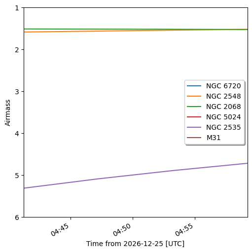

```python
chile_time_grid = time_grid_from_range(chile_observing, time_resolution = 0.1 * u.h)

fig, ax = plt.subplots(figsize = (5, 5), constrained_layout = True)

for target in targets:
    ax = plot_airmass(target, chile_location, chile_time_grid, min_airmass = 1.0, max_airmass = 6.0)

ax.legend(loc=0,shadow=True);
```

```python
indonesia_midnight = indonesia_location.midnight(indonesia_noon, which='nearest')
print(indonesia_midnight.to_datetime(indonesia_location.timezone))

print(indonesia_location.target_is_up(indonesia_midnight, target1))
print(indonesia_location.target_is_up(indonesia_midnight, target2))
print(indonesia_location.target_is_up(indonesia_midnight, target3))
print(indonesia_location.target_is_up(indonesia_midnight, target4))
print(indonesia_location.target_is_up(indonesia_midnight, target5))
print(indonesia_location.target_is_up(indonesia_midnight, target6))

#Here I establish that only four targets are observable
```

```
2026-12-25 00:07:40.674334+08:00
False
True
True
False
True
True
```

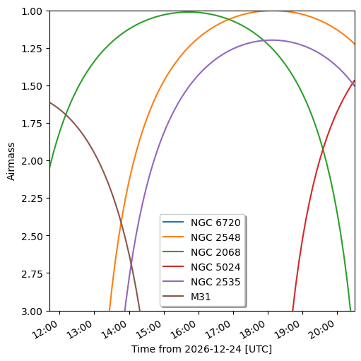

```python
indonesia_time_grid = time_grid_from_range(indonesia_observing, time_resolution = 0.1 * u.h)

fig, ax = plt.subplots(figsize = (5, 5), constrained_layout = True)

for target in targets:
    ax = plot_airmass(target, indonesia_location, indonesia_time_grid, ax = ax)

ax.legend(loc=0,shadow=True);
```

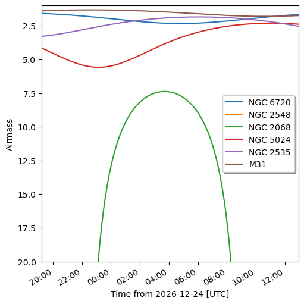

```python
canada_time_grid = time_grid_from_range(canada_observing, time_resolution = 0.1 * u.h)

fig, ax = plt.subplots(figsize = (5, 5), constrained_layout = True)

for target in targets:
    ax = plot_airmass(target, canada_location, canada_time_grid, ax = ax, max_airmass = 20)

ax.legend(loc=0,shadow=True);
```

### Due Mon Feb 23 - 1 pm

- `File -> Download as -> HTML (.html)`
- `upload your .html file to the class Canvas page`